# Statistical Modelling_ Group 9 Assignment 1

Duc Anh Nguyen,Lakshman Duggirala,Naveen Vanka,Sreya Pendyala

2024-01-16

# Part I: Initial exploration

### 1. Read the two files FAA1.xls (800 flights) and FAA2.xls into R.

```r
library(readxl)
flight1 <- FAA1 <- read_excel("D:/Statsical modelling/Home work 1/FAA1.xls")
flight2 <- FAA1 <- read_excel("D:/Statsical modelling/Home work 1/FAA2.xls")
```

### 2.Check the structure of each data set using the str() function. For each data set, what is the sample

size and number of variables? Are there any differences between the two data sets?

```r
str(flight1)
```

```
## tibble [800 × 8] (S3: tbl_df/tbl/data.frame)
##  $ aircraft    : chr [1:800] "boeing" "boeing" "boeing" "boeing" ...
##  $ duration    : num [1:800] 98.5 125.7 112 196.8 90.1 ...
##  $ no_pasg     : num [1:800] 53 69 61 56 70 55 54 57 61 56 ...
##  $ speed_ground: num [1:800] 107.9 101.7 71.1 85.8 59.9 ...
##  $ speed_air   : num [1:800] 109 103 NA NA NA ...
##  $ height      : num [1:800] 27.4 27.8 18.6 30.7 32.4 ...
##  $ pitch       : num [1:800] 4.04 4.12 4.43 3.88 4.03 ...
##  $ distance    : num [1:800] 3370 2988 1145 1664 1050 ...
```

```r
str(flight2)
```

```
## tibble [150 × 7] (S3: tbl_df/tbl/data.frame)
##  $ aircraft    : chr [1:150] "boeing" "boeing" "boeing" "boeing" ...
##  $ no_pasg     : num [1:150] 53 69 61 56 70 55 54 57 61 56 ...
##  $ speed_ground: num [1:150] 107.9 101.7 71.1 85.8 59.9 ...
##  $ speed_air   : num [1:150] 109 103 NA NA NA ...
##  $ height      : num [1:150] 27.4 27.8 18.6 30.7 32.4 ...
##  $ pitch       : num [1:150] 4.04 4.12 4.43 3.88 4.03 ...
##  $ distance    : num [1:150] 3370 2988 1145 1664 1050 ...
```

**FAA1 comprises 800 rows and 8 columns, whereas FAA2 consists of 150 rows and 7 columns, lacking the duration column present in FAA1.**

### 3. Merge the two data sets. Are there any duplicate observations? If there are duplicate observations,

### what actions would you take before doing any further analysis?

```r
merged_data <- merge(flight1, flight2,
                     by = c("aircraft", "no_pasg", "speed_ground", "speed_air", "height", "pitch", "distance"),
                     all = TRUE, sort = FALSE)
print(head(merged_data))
```

```
##   aircraft no_pasg speed_ground speed_air   height    pitch distance  duration
## 1   boeing      53    107.91568  109.3284 27.41892 4.043515 3369.836  98.47909
## 2   boeing      69    101.65559  102.8514 27.80472 4.117432 2987.804 125.73330
## 3   boeing      61     71.05196        NA 18.58939 4.434043 1144.922 112.01700
## 4   boeing      56     85.81333        NA 30.74460 3.884236 1664.218 196.82569
## 5   boeing      70     59.88853        NA 32.39769 4.026096 1050.264  90.09538
## 6   boeing      55     75.01434        NA 41.21496 4.203853 1627.068 137.59582
```

```r
duplicate_rows <- merged_data[duplicated(merged_data), ]

print(duplicate_rows)
```

```
## [1] aircraft     no_pasg      speed_ground speed_air    height
## [6] pitch        distance     duration
## <0 rows> (or 0-length row.names)
```

### 4. Check the structure of the combined data set. Provide an appropriate (and concise) summary of each variable.

```r
summary(merged_data)
```

```
##    aircraft            no_pasg      speed_ground      speed_air
##  Length:850         Min.   :29.0   Min.   : 27.74   Min.   : 90.00
##  Class :character   1st Qu.:55.0   1st Qu.: 65.90   1st Qu.: 96.25
##  Mode  :character   Median :60.0   Median : 79.64   Median :101.15
##                     Mean   :60.1   Mean   : 79.45   Mean   :103.80
##                     3rd Qu.:65.0   3rd Qu.: 92.06   3rd Qu.:109.40
##                     Max.   :87.0   Max.   :141.22   Max.   :141.72
##                                                     NA's   :642
##      height           pitch          distance          duration
##  Min.   :-3.546   Min.   :2.284   Min.   :  34.08   Min.   : 14.76
##  1st Qu.:23.314   1st Qu.:3.642   1st Qu.: 883.79   1st Qu.:119.49
##  Median :30.093   Median :4.008   Median :1258.09   Median :153.95
##  Mean   :30.144   Mean   :4.009   Mean   :1526.02   Mean   :154.01
##  3rd Qu.:36.993   3rd Qu.:4.377   3rd Qu.:1936.95   3rd Qu.:188.91
##  Max.   :59.946   Max.   :5.927   Max.   :6533.05   Max.   :305.62
##                                                     NA's   :50
```

### 5. At this point, you are asked by FAA agents to prepare ONE presentation slide to summarize your

findings (3–7 bullet points will suffice). What observations will you bring to the attention of the agents?

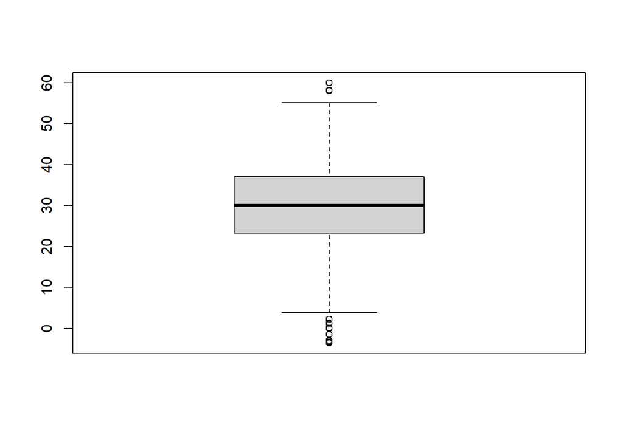

```r
boxplot(merged_data$height)
```

# Part II: Data cleaning and further exploration

### 6. Are there any “abnormal” values in the data set? (You can refer to the data dictionary for criteria defining “normal/abnormal” values for each column.) Remove any rows that contain any “abnormal” values and report how many rows you have removed.

```
##    aircraft            no_pasg       speed_ground      speed_air
##  Length:831         Min.   :29.00   Min.   : 33.57   Min.   : 90.00
##  Class :character   1st Qu.:55.00   1st Qu.: 66.20   1st Qu.: 96.23
##  Mode  :character   Median :60.00   Median : 79.79   Median :101.12
##                     Mean   :60.06   Mean   : 79.54   Mean   :103.48
##                     3rd Qu.:65.00   3rd Qu.: 91.91   3rd Qu.:109.36
##                     Max.   :87.00   Max.   :132.78   Max.   :132.91
##                                                      NA's   :628
##      height           pitch          distance          duration
##  Min.   : 6.228   Min.   :2.284   Min.   :  41.72   Min.   : 41.95
##  1st Qu.:23.530   1st Qu.:3.640   1st Qu.: 893.28   1st Qu.:119.63
##  Median :30.167   Median :4.001   Median :1262.15   Median :154.28
##  Mean   :30.458   Mean   :4.005   Mean   :1522.48   Mean   :154.78
##  3rd Qu.:37.004   3rd Qu.:4.370   3rd Qu.:1936.63   3rd Qu.:189.66
##  Max.   :59.946   Max.   :5.927   Max.   :5381.96   Max.   :305.62
##                                                     NA's   :50
```

```
## 'data.frame':    831 obs. of  8 variables:
##  $ aircraft    : chr  "boeing" "boeing" "boeing" "boeing" ...
##  $ no_pasg     : num  53 69 61 56 70 55 54 57 61 56 ...
##  $ speed_ground: num  107.9 101.7 71.1 85.8 59.9 ...
##  $ speed_air   : num  109 103 NA NA NA ...
##  $ height      : num  27.4 27.8 18.6 30.7 32.4 ...
##  $ pitch       : num  4.04 4.12 4.43 3.88 4.03 ...
##  $ distance    : num  3370 2988 1145 1664 1050 ...
##  $ duration    : num  98.5 125.7 112 196.8 90.1 ...
```

**Nineteen rows have been filtered based on the criteria outlined in the data dictionary.**

### 7.Repeat Step 4. Can you find a single visualization that helps to summarize the data?

```r
summary(filtered_data)
```

```
##    aircraft            no_pasg       speed_ground      speed_air
##  Length:831         Min.   :29.00   Min.   : 33.57   Min.   : 90.00
##  Class :character   1st Qu.:55.00   1st Qu.: 66.20   1st Qu.: 96.23
##  Mode  :character   Median :60.00   Median : 79.79   Median :101.12
##                     Mean   :60.06   Mean   : 79.54   Mean   :103.48
##                     3rd Qu.:65.00   3rd Qu.: 91.91   3rd Qu.:109.36
##                     Max.   :87.00   Max.   :132.78   Max.   :132.91
##                                                      NA's   :628
##      height           pitch          distance          duration
##  Min.   : 6.228   Min.   :2.284   Min.   :  41.72   Min.   : 41.95
##  1st Qu.:23.530   1st Qu.:3.640   1st Qu.: 893.28   1st Qu.:119.63
##  Median :30.167   Median :4.001   Median :1262.15   Median :154.28
##  Mean   :30.458   Mean   :4.005   Mean   :1522.48   Mean   :154.78
##  3rd Qu.:37.004   3rd Qu.:4.370   3rd Qu.:1936.63   3rd Qu.:189.66
##  Max.   :59.946   Max.   :5.927   Max.   :5381.96   Max.   :305.62
##                                                     NA's   :50
```

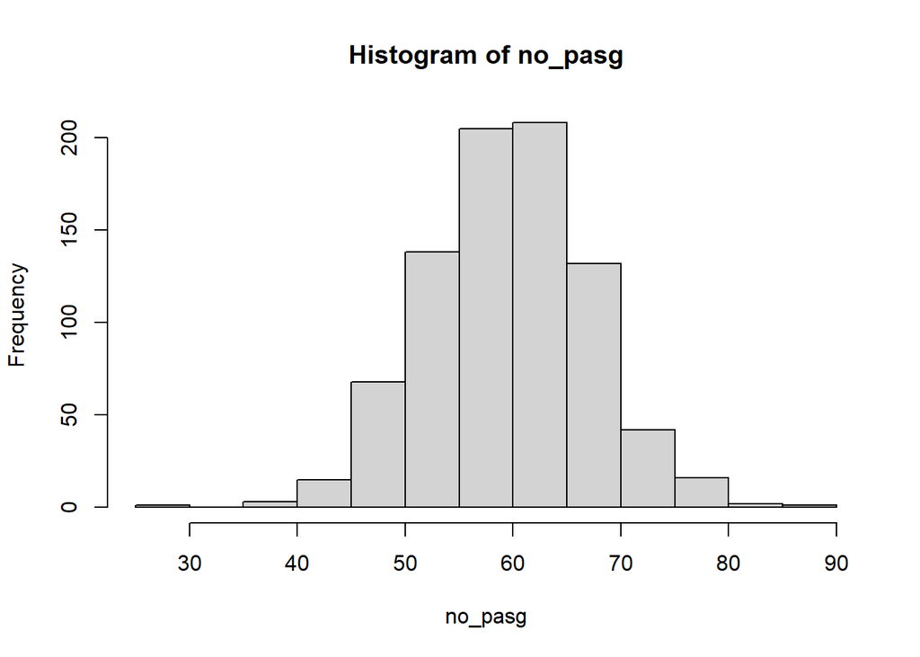

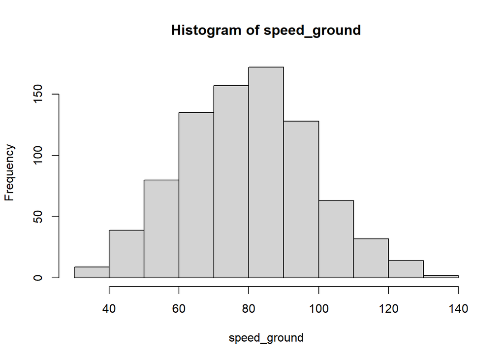

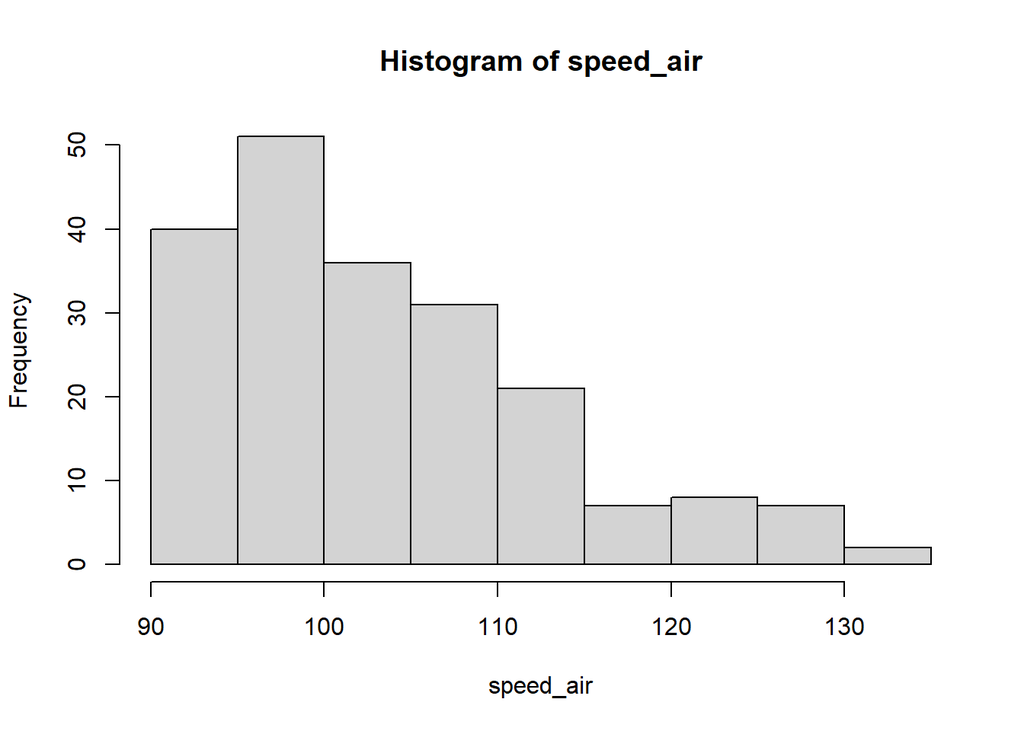

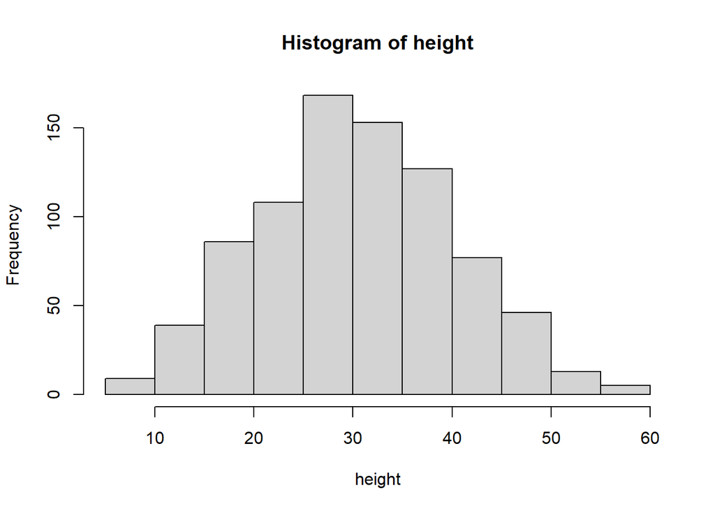

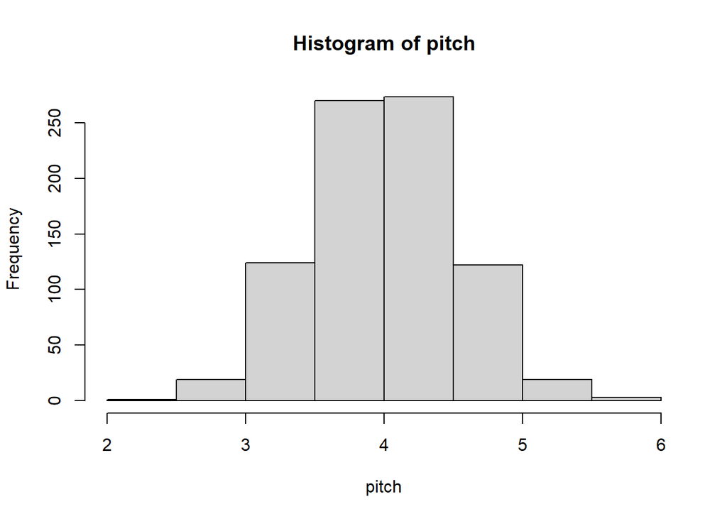

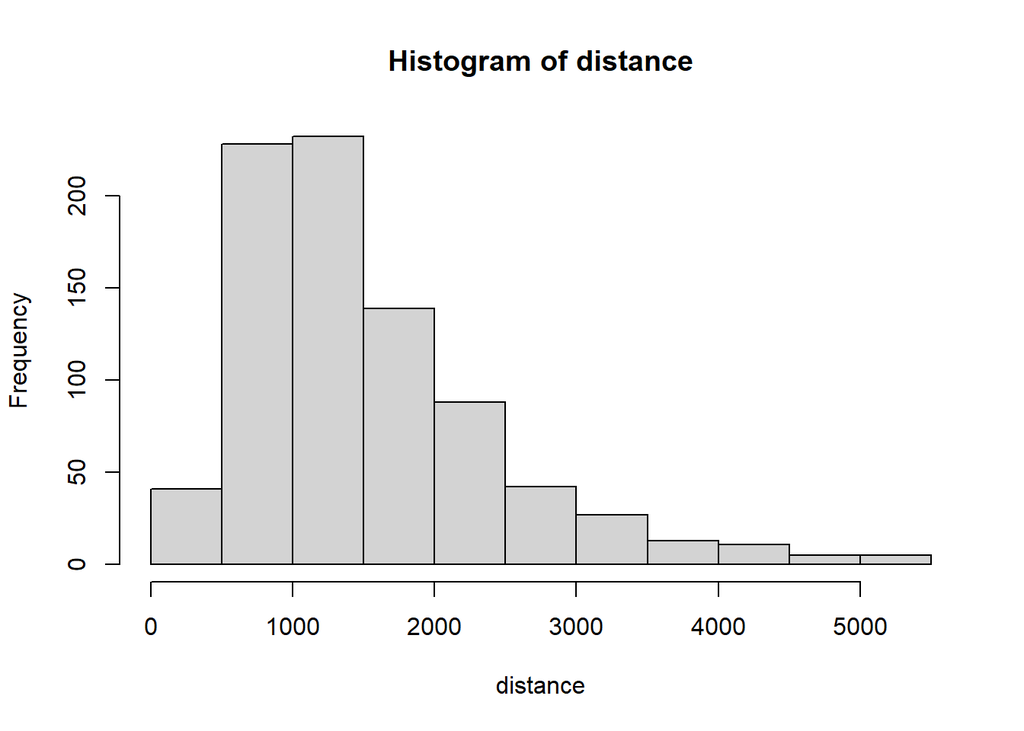

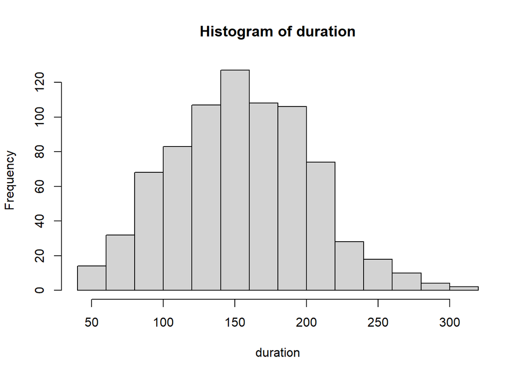

```r
for (column_name in names(filtered_data)) {

    if (is.numeric(filtered_data[[column_name]])) {
        hist(filtered_data[[column_name]], main = paste("Histogram of", column_name), xlab = column_name)
    }
}
```

### 8.Prepare another presentation slide (or 3–7 bullet points) to summarize your findings obtained from the cleaned data set. We have filtered 19 rows based based on the criteria provided in the data dictionary.

- **Airspeed information is unavailable for 75% of the dataset.**
- **Duration data is absent in the FAA2 file.**
- **The distribution of variables, excluding airspeed and distance, appears to adhere to a normal distribution. However, airspeed and distance exhibit right-skewed distributions.**

# 10. Compute the pairwise correlation between the distance and each

# predictor (i.e., every other column; consider re-encoding aircraft

# as 0/1 for boeing/airbus). Provide a table that ranks the predictors

# in descending order based on the strength (i.e., absolute value) of the correlations.

```
#### This table should contain three columns:

#### • the names of variables

#### • the size of the correlation

#### • the direction of the correlation (i.e., positive or negative).
```

```r
filtered_data$aircraft <- ifelse(filtered_data$aircraft == "boeing", 0, 1)

cor_table <- data.frame(cor(filtered_data[1:7], filtered_data$distance, use="complete.obs"))


colnames(cor_table) <- c("Size_Of_Correlation")


cor_table <- tibble::rownames_to_column(cor_table, "Variable") %>%
  mutate(Correlation_Dir = ifelse(Size_Of_Correlation < 0, "-ve", "+ve")) %>%
  arrange(desc(abs(Size_Of_Correlation)))


cor_table
```

```
##       Variable Size_Of_Correlation Correlation_Dir
## 1     distance          1.00000000             +ve
## 2    speed_air          0.94209714             +ve
## 3 speed_ground          0.92658618             +ve
## 4     aircraft         -0.17992145             -ve
## 5       height          0.06814248             +ve
## 6        pitch          0.04234550             +ve
## 7      no_pasg         -0.03994273             -ve
```

Refer to this table as Table 1, which will be used for comparison with our analysis later.

### 11. Construct a scatter plot between the response and each predictor. Do you think the correlation strength observed in these plots is consistent with the results displayed in Table 1?

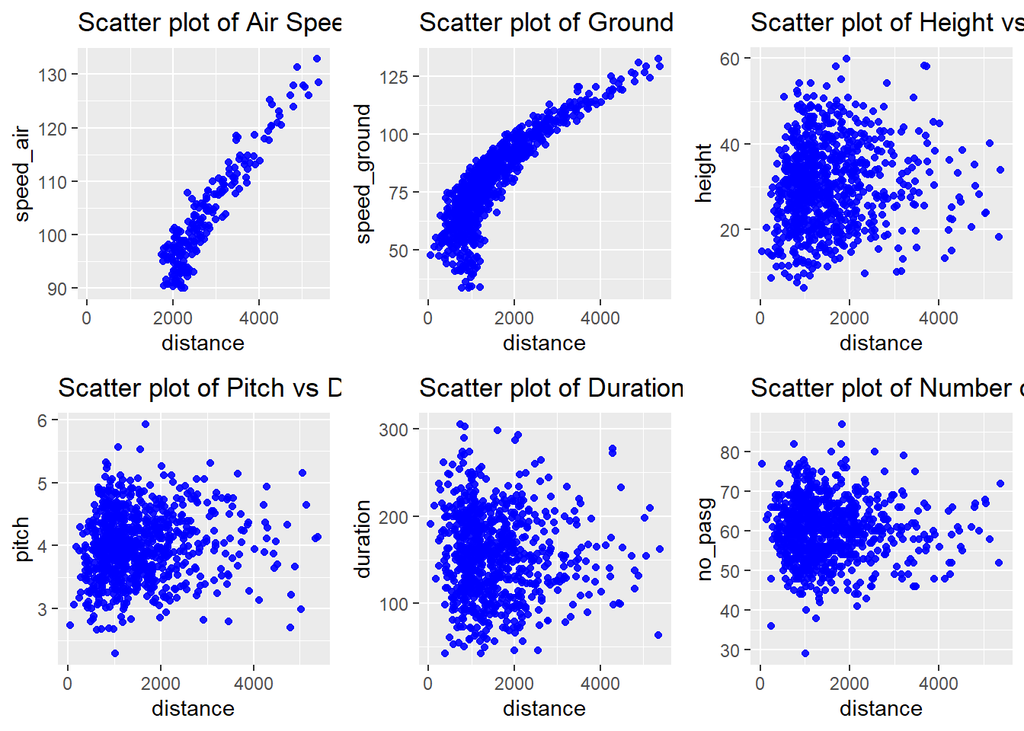

```r
library(ggplot2)
library(gridExtra)
# Air Speed
plot_1 <- ggplot(filtered_data, aes(x = distance, y = speed_air)) +
  geom_point(alpha = 0.9, color='blue') +
  labs(y = "speed_air", title = "Scatter plot of Air Speed vs Distance")

# Ground Speed
plot_2 <- ggplot(filtered_data, aes(x = distance, y = speed_ground)) +
  geom_point(alpha = 0.9, color='blue') +
  labs(y = "speed_ground", title = "Scatter plot of Ground Speed vs Distance")

# Height
plot_3 <- ggplot(filtered_data, aes(x = distance, y = height)) +
  geom_point(alpha = 0.9, color='blue') +
  labs(y = "height", title = "Scatter plot of Height vs Distance")

# Pitch
plot_4 <- ggplot(filtered_data, aes(x = distance, y = pitch)) +
  geom_point(alpha = 0.9, color='blue') +
  labs(y = "pitch", title = "Scatter plot of Pitch vs Distance")

# Duration
plot_5 <- ggplot(filtered_data, aes(x = distance, y = duration)) +
  geom_point(alpha = 0.9, color='blue') +
  labs(y = "duration", title = "Scatter plot of Duration vs Distance")

# Number of Passengers
plot_6 <- ggplot(filtered_data, aes(x = distance, y = no_pasg)) +
  geom_point(alpha = 0.9, color='blue') +
  labs(y = "no_pasg", title = "Scatter plot of Number of Passengers vs Distance")

# Arrange all plots in a grid
gridExtra::grid.arrange(plot_1, plot_2, plot_3, plot_4, plot_5, plot_6, ncol = 3)
```

### 12. Discuss any issues of including aircraft in this analysis. Does the correlation analysis make sense? How else might you analyse this variable and it’s associative importance? We see strong correlation between distance and ground speed and air speed.

A robust correlation is evident between distance, ground speed, and airspeed, highlighting a notable relationship among these variables.

# Part IV: Regression using a single factor each time

### 13. Regress distance on each of the predictors. Provide a table that ranks the factors based on itssignificance. The smaller the p-value, the more “important” the predictor. Organize the results in a new table, called Table 2, that’s similar to Table 1

```r
# Perform linear regression for each predictor
model <- lapply(1:7, function(i) lm(filtered_data$distance ~ filtered_data[[i]]))

# Extract p-values
pvalues <- sapply(model, function(m) summary(m)$coefficients[2, 4])
# Create Table 2
table2 <- data.frame(Variable = colnames(filtered_data[, 1:7]), PValue = pvalues)
table2 <- table2 %>% arrange(PValue)

# Display Table 2
print(table2)
```

```
##       Variable        PValue
## 1     distance  0.000000e+00
## 2 speed_ground 4.766371e-252
## 3    speed_air  2.500461e-97
## 4     aircraft  3.526194e-12
## 5       height  4.123860e-03
## 6        pitch  1.208124e-02
## 7      no_pasg  6.092520e-01
```

### 14. Standardize each predictor by subtracting its mean and dividing by its standard deviation (i.e., so each predictor is centered with unit variance). Regress distance on each of the standardized predictors. Provide a table that ranks the predictors based on the size of the regression coefficients. The larger the size, the more “important” the predictor. Store the results in a new table, called Table 3; be sure to include a third column giving the sign of the corresponding coefficient.

```r
# Assuming filtered_data is already loaded and prepared

# Convert factor variables with only one level to numeric
filtered_data <- filtered_data %>%
  mutate(across(where(~ is.factor(.) && nlevels(.) == 1), as.numeric))

# Standardize numeric columns
numeric_columns <- sapply(filtered_data, is.numeric)

FAA_Stand <- data.frame(scale(filtered_data[numeric_columns]))
names(FAA_Stand) <- names(filtered_data)[numeric_columns]

# Add 'distance' column back if it's numeric and was scaled
if (numeric_columns["distance"]) {
    FAA_Stand$distance <- filtered_data$distance
}

# Perform linear regression for each standardized predictor
model_stand <- lapply(names(FAA_Stand)[names(FAA_Stand) != "distance"], function(var) {
    lm(as.formula(paste("distance ~", var)), data = FAA_Stand)
})

# Extract coefficients
coef <- sapply(model_stand, function(m) coef(m)[2])

# Create Table 3
table3 <- data.frame(Variable = names(coef), Coefficient = coef)
table3 <- table3 %>% arrange(desc(abs(Coefficient))) %>% mutate(coef_direction = ifelse(Coefficient < 0, "-ve", "+ve"))

# Display Table 3
print(table3)
```

```
##                  Variable Coefficient coef_direction
## speed_ground speed_ground   776.44740            +ve
## speed_air       speed_air   774.34654            +ve
## aircraft         aircraft  -213.45802            -ve
## height             height    89.10606            +ve
## pitch               pitch    78.00693            +ve
## duration         duration   -46.48013            -ve
## no_pasg           no_pasg   -15.91595            -ve
```

### 15.Compare Tables 1, 2, and 3. Are the results consistent? At this point, you will meet with the FAA agents again. Please provide a single table than ranks all the predictors based on their relative importance in predicting distance. We’ll call it Table 0.

```r
table0<-merge(x=table2,y=table3,by="Variable")
table0<-merge(x=table0,y=table3,by="Variable")

table0
```

```
##       Variable        PValue Coefficient.x coef_direction.x Coefficient.y
## 1     aircraft  3.526194e-12    -213.45802              -ve    -213.45802
## 2       height  4.123860e-03      89.10606              +ve      89.10606
## 3      no_pasg  6.092520e-01     -15.91595              -ve     -15.91595
## 4        pitch  1.208124e-02      78.00693              +ve      78.00693
## 5    speed_air  2.500461e-97     774.34654              +ve     774.34654
## 6 speed_ground 4.766371e-252     776.44740              +ve     776.44740
##   coef_direction.y
## 1              -ve
## 2              +ve
## 3              -ve
## 4              +ve
## 5              +ve
## 6              +ve
```

```r
summary(filtered_data$speed_ground)
```

```
##    Min. 1st Qu.  Median    Mean 3rd Qu.    Max.
##   33.57   66.20   79.79   79.54   91.91  132.78
```

```r
summary(filtered_data$distance)
```

```
##    Min. 1st Qu.  Median    Mean 3rd Qu.    Max.
##   41.72  893.28 1262.15 1522.48 1936.63 5381.96
```

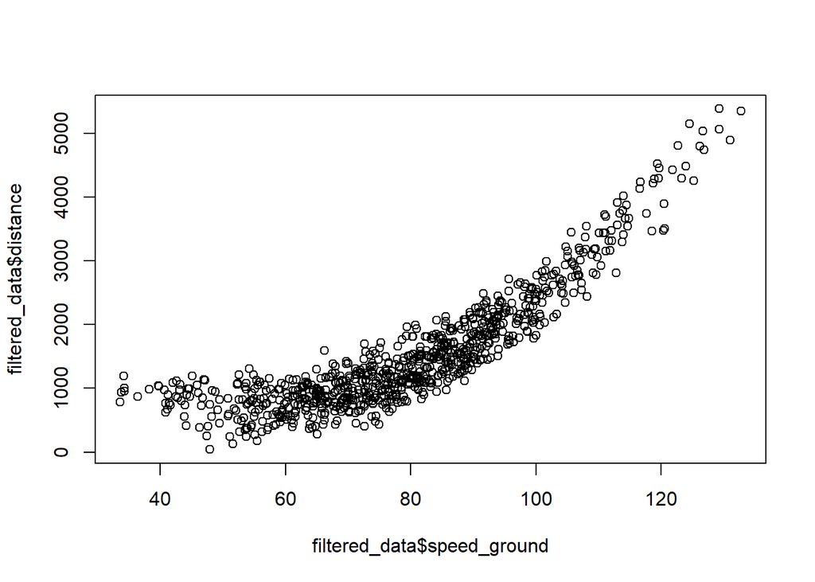

```r
plot(filtered_data$speed_ground, filtered_data$distance)
```

# **Part V: Checking for multicollinearity**

### 16. Compare the regression coefficients of the three models below: Do you observe any potential problems in the sign/significance of each term? Check the correlation between speed_ground and speed_air. If you had to choose between one of these two variables to include in the model, which would it be and why? What other methods could you use to deal with potential multicollinearity? Are there any drawbacks to these other methods?

```r
# Load necessary libraries

model_1 <- lm(distance ~ speed_ground, data = FAA_Stand)
model_2 <- lm(distance ~ speed_air, data = FAA_Stand)
model_3 <- lm(distance ~ speed_ground + speed_air, data = FAA_Stand)

summary(model_1)$coefficients[,1]
```

```
##  (Intercept) speed_ground
##    1522.4829     776.4474
```

```r
summary(model_2)$coefficients[,1]
```

```
## (Intercept)   speed_air
##   2774.6729    774.3465
```

```r
summary(model_3)$coefficients[,1]
```

```
##  (Intercept) speed_ground    speed_air
##    3117.7445    -269.2959     914.8089
```

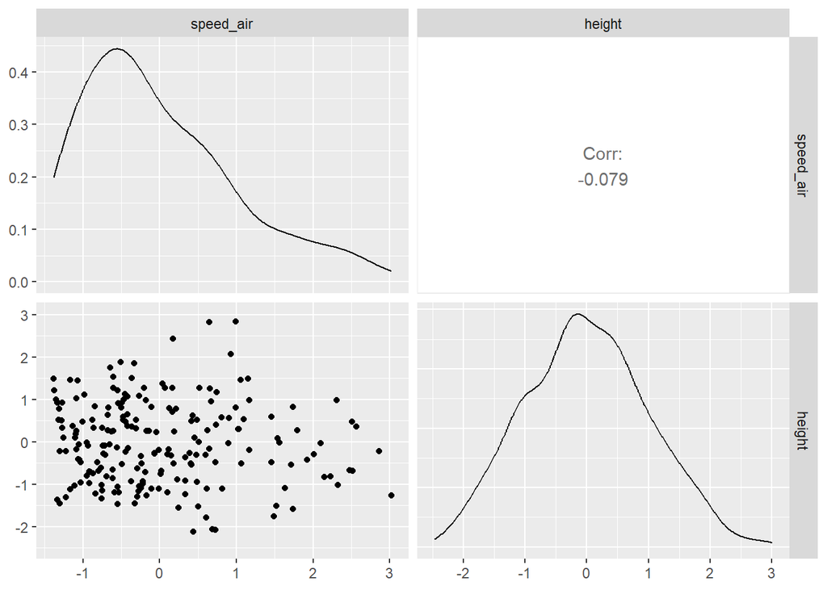

```r
GGally::ggpairs(data = FAA_Stand, columns =4:5 )
```

# Part VI: Variable selection based on Table

### 17. Suppose in Table , the variable ranking is as follows: X1, X2, X3, X4, X5, and X6, where X1 and X6 are the most important and least important predictors, respectively. Please fit the following six models

```r
# Assuming 'filtered_data' is already loaded and prepared

# Standardize numeric columns
numeric_columns <- sapply(filtered_data, is.numeric)
FAA_Stand <- data.frame(scale(filtered_data[numeric_columns]))
names(FAA_Stand) <- names(filtered_data)[numeric_columns]

# Add 'distance' column back if it's numeric and was scaled
if (numeric_columns["distance"]) {
    FAA_Stand$distance <- filtered_data$distance
}

# Include non-numeric variables (like 'aircraft') in FAA_Stand
FAA_Stand$aircraft <- filtered_data$aircraft

# Now proceed with your linear regression models
var_selection <- c()

var_selection[1] <- summary(lm(distance ~ speed_ground , data = FAA_Stand))$r.squared
var_selection[2] <- summary(lm(distance ~ speed_ground + aircraft, data = FAA_Stand))$r.squared
var_selection[3] <- summary(lm(distance ~ speed_ground + aircraft + height, data = FAA_Stand))$r.squared
var_selection[4] <- summary(lm(distance ~ speed_ground + aircraft + height + duration, data = FAA_Stand))$r.squared
var_selection[5] <- summary(lm(distance ~ speed_ground + aircraft + height + duration + pitch, data = FAA_Stand))$r.squared
var_selection[6] <- summary(lm(distance ~ speed_ground + aircraft + height + duration + pitch + no_pasg, data = FAA_Stand))$r.squared

parameters <- c(1:6)

var_selection_result <- data.frame(parameters, var_selection)
print(var_selection_result)
```

```
##   parameters var_selection
## 1          1     0.7503784
## 2          2     0.8251319
## 3          3     0.8488989
## 4          4     0.8503048
## 5          5     0.8504184
## 6          6     0.8506023
```

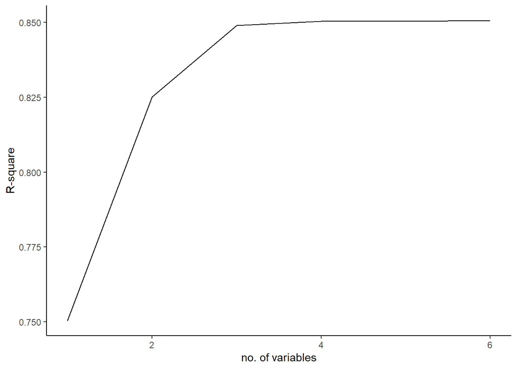

```r
var_selection_result %>%
  ggplot(aes(x = parameters , y = var_selection)) +
  geom_line() +
  xlab("no. of variables") +
  ylab("R-square") +
  theme_classic()
```

**Beyond the inclusion of three variables, the R-squared value ceases to increase, indicating that the addition of new variables is not contributing to the explanation of additional variation.**

### 18. Repeat 17, but use adjusted R2 instead.

```r
var_selection_adj <-c()

var_selection_adj[1] <- summary(lm(distance ~ speed_ground , data = FAA_Stand))$adj.r.squared
var_selection_adj[2] <- summary(lm(distance ~ speed_ground + aircraft  , data = FAA_Stand))$adj.r.squared
var_selection_adj[3] <- summary(lm(distance ~ speed_ground + aircraft + height, data = FAA_Stand))$adj.r.squared
var_selection_adj[4] <- summary(lm(distance ~ speed_ground + aircraft + height + duration , data = FAA_Stand))$adj.r.squared
var_selection_adj[5] <- summary(lm(distance ~ speed_ground + aircraft + height + duration + pitch , data = FAA_Stand))$adj.r.squared
var_selection_adj[6] <- summary(lm(distance ~ speed_ground + aircraft + height + duration + pitch + no_pasg, data = FAA_Stand))$adj.r.squared

parameters <-c(1:6)

var_selection_result_adj <- data.frame(var_selection_adj,parameters)
var_selection_result_adj
```

```
##   var_selection_adj parameters
## 1         0.7500773          1
## 2         0.8247095          2
## 3         0.8483508          3
## 4         0.8495332          4
## 5         0.8494534          5
## 6         0.8494442          6
```

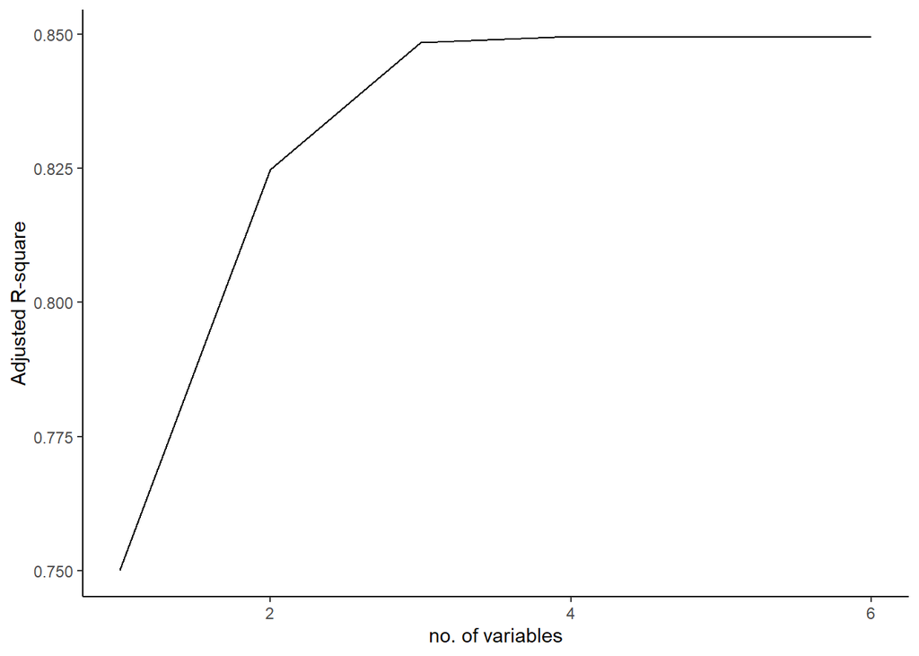

```r
var_selection_result_adj %>%
  ggplot(aes(x = parameters , y = var_selection_adj)) +
  geom_line() +
  xlab("no. of variables") +
  ylab("Adjusted R-square") +
  theme_classic()
```

### 19.Repeat 17. but use AIC instead

```r
aic_method <- c()
aic_method[1] <- AIC(lm(distance ~ speed_ground , data = FAA_Stand))
aic_method[2] <- AIC(lm(distance ~ speed_ground + aircraft  , data = FAA_Stand))
aic_method[3] <- AIC(lm(distance ~ speed_ground + aircraft + height, data = FAA_Stand))
aic_method[4] <- AIC(lm(distance ~ speed_ground + aircraft + height + duration, data = FAA_Stand))
aic_method[5] <- AIC(lm(distance ~ speed_ground + aircraft + height + duration + pitch , data = FAA_Stand))
aic_method[6] <- AIC(lm(distance ~ speed_ground + aircraft + height + duration + pitch + no_pasg, data = FAA_Stand))

aic_method
```

```
## [1] 12508.81 12215.05 12095.65 11377.43 11378.84 11379.88
```

```r
parameters <-c(1:6)

aic_method_selection <- data.frame(aic_method,parameters)
aic_method_selection
```

```
##   aic_method parameters
## 1   12508.81          1
## 2   12215.05          2
## 3   12095.65          3
## 4   11377.43          4
## 5   11378.84          5
## 6   11379.88          6
```

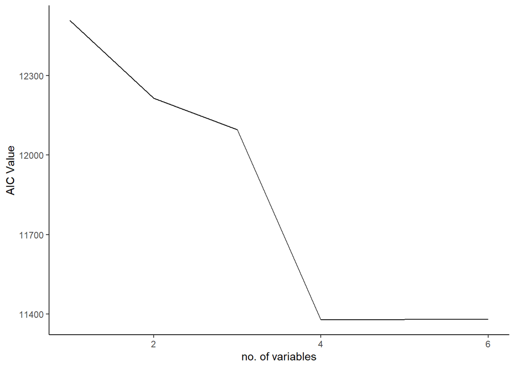

```r
aic_method_selection %>%
  ggplot(aes(x = parameters , y = aic_method)) +
  geom_line() +
  xlab("no. of variables") +
  ylab("AIC Value") +
  theme_classic()
```

**The Akaike Information Criterion (AIC) exhibits a decrease until the model with four variables, after which its value stabilizes. According to the AIC, the optimal choice would be a model with four variables.**

### 20. Compare the results 17–19. What variables would you select to build a predictive model for predicting distance? Any problems with this approach?

# Part VII: Variable selection using automatic search procedures

### 21.Use the R function StepAIC() from package MASS to perform forward variable selection; see ?MASS:stepAIC for details and usage examples (or ask in the class Teams chat). Compare the result with those from 19).

```r
library(MASS)
FAA_Stand_Imputed <- FAA_Stand
numeric_columns <- sapply(FAA_Stand_Imputed, is.numeric)
FAA_Stand_Imputed[numeric_columns] <- lapply(FAA_Stand_Imputed[numeric_columns], function(x) ifelse(is.na(x), mean(x, na.rm = TRUE), x))

# Start with the minimal model (only intercept)
start_model <- lm(distance ~ 1, data = FAA_Stand_Imputed)

# Perform forward selection
forward_model <- stepAIC(start_model, scope = list(lower = start_model, upper = lm(distance ~ ., data = FAA_Stand_Imputed)), direction = "forward")
```

```
## Start:  AIC=11299.8
## distance ~ 1
##
##                Df Sum of Sq       RSS   AIC
## + speed_ground  1 500382567 166457762 10148
## + speed_air     1 121121738 545718591 11135
## + aircraft      1  37818390 629021939 11253
## + height        1   6590108 660250221 11294
## + pitch         1   5050617 661789712 11296
## + duration      1   1685114 665155215 11300
## <none>                      666840329 11300
## + no_pasg       1    210253 666630076 11302
##
## Step:  AIC=10148.53
## distance ~ speed_ground
##
##             Df Sum of Sq       RSS     AIC
## + aircraft   1  49848656 116609106  9854.8
## + speed_air  1  29512031 136945731  9988.4
## + height     1  14916377 151541385 10072.5
## + pitch      1   9765095 156692668 10100.3
## <none>                   166457762 10148.5
## + no_pasg    1    207528 166250234 10149.5
## + duration   1     51669 166406094 10150.3
##
## Step:  AIC=9854.77
## distance ~ speed_ground + aircraft
##
##             Df Sum of Sq       RSS    AIC
## + speed_air  1  31537796  85071310 9594.7
## + height     1  15848830 100760276 9735.4
## + pitch      1    455453 116153653 9853.5
## <none>                   116609106 9854.8
## + no_pasg    1     87171 116521935 9856.1
## + duration   1      8445 116600661 9856.7
##
## Step:  AIC=9594.72
## distance ~ speed_ground + aircraft + speed_air
##
##            Df Sum of Sq      RSS    AIC
```

[output cut: 15 more lines]

```
## Step:  AIC=9410.04
## distance ~ speed_ground + aircraft + speed_air + height + pitch
##
##            Df Sum of Sq      RSS    AIC
## + no_pasg   1    212814 67578752 9409.4
## <none>                  67791566 9410.0
## + duration  1     13343 67778223 9411.9
##
## Step:  AIC=9409.43
## distance ~ speed_ground + aircraft + speed_air + height + pitch +
##     no_pasg
##
##            Df Sum of Sq      RSS    AIC
## <none>                  67578752 9409.4
## + duration  1     17640 67561113 9411.2
```

```r
# Print the summary of the final model
summary(forward_model)
```

```
##
## Call:
## lm(formula = distance ~ speed_ground + aircraft + speed_air +
##     height + pitch + no_pasg, data = FAA_Stand_Imputed)
##
## Residuals:
##     Min      1Q  Median      3Q     Max
## -696.77 -206.02  -52.75  187.72 1209.78
##
## Coefficients:
##              Estimate Std. Error t value Pr(>|t|)
## (Intercept)  1784.769     15.115 118.079   <2e-16 ***
## speed_ground  742.599     10.308  72.041   <2e-16 ***
## aircraft     -490.900     21.321 -23.024   <2e-16 ***
## speed_air     416.247     20.865  19.950   <2e-16 ***
## height        143.419      9.976  14.376   <2e-16 ***
## pitch          20.930     10.638   1.967   0.0495 *
## no_pasg       -16.035      9.955  -1.611   0.1076
## ---
## Signif. codes:  0 '***' 0.001 '**' 0.01 '*' 0.05 '.' 0.1 ' ' 1
##
## Residual standard error: 286.4 on 824 degrees of freedom
## Multiple R-squared:  0.8987, Adjusted R-squared:  0.8979
## F-statistic:  1218 on 6 and 824 DF,  p-value: < 2.2e-16
```

```r
## Comparison with 19th question
## Checking Multicollinearity
library(car)
vif_model <- lm(distance ~ speed_ground + aircraft + speed_air + height + pitch + no_pasg, data = FAA_Stand_Imputed)
vif(vif_model)
```

```
## speed_ground     aircraft    speed_air       height        pitch      no_pasg
##     1.075351     1.146104     1.072247     1.007233     1.145357     1.002852
```

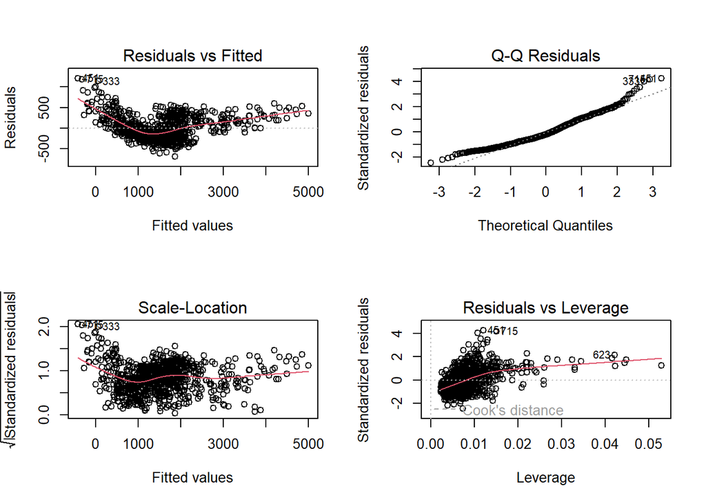

```r
#Residual Analysis:
par(mfrow=c(2,2))
plot(vif_model)
```

```r
## Cross Validation
library(boot)
set.seed(123) # for reproducibility
cv_model <- cv.glm(data = FAA_Stand_Imputed, glmfit = vif_model, K = 10)
cv_model$delta
```

```
## [1] NaN NaN
```

# Part VIII. The Mirage of variable selection

Variable selection requires spending information from the system in order to make decisions on what variable to keep. However, the root problem is that the Probability of selecting the right variables is 0, unless you have millions upon millions observations and not too many candidate variables.

So you can also get a false negative where variables that are not selected turns out to be important and vice versa.Frank also mentioned that it is very uncommon for someone to replicate feature selection and have the same results as the work they try to replicate.

Frank mentioned that if your goal is pure prediction, having variable selection is not important. However, the most stable model selection method he recommends is full flexible Bayesian model with carefully chosen shinkage priors.